# 6. ARIMA Modeling

### Preliminary Analysis

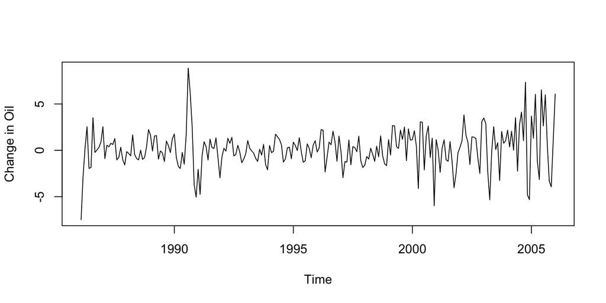

```r
  #- Take difference of lag 1
  plot(diff(Oil), ylab='Change in Oil',type='l')
```

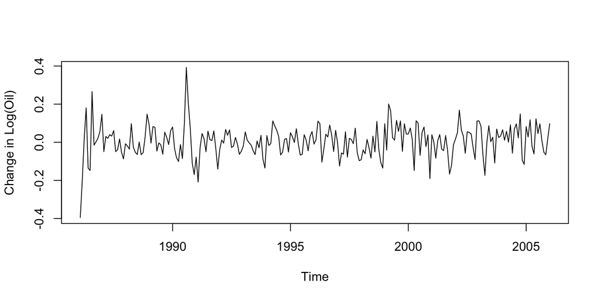

```r
  #- Take log difference of lag 1
  plot(diff(log(Oil)),ylab='Change in Log(Oil)',type='l')
```

```r
  Stationarity.tests(diff(log(Oil)))
```

```
##        KPSS  ADF   PP
## p-val:  0.1 0.01 0.01
```

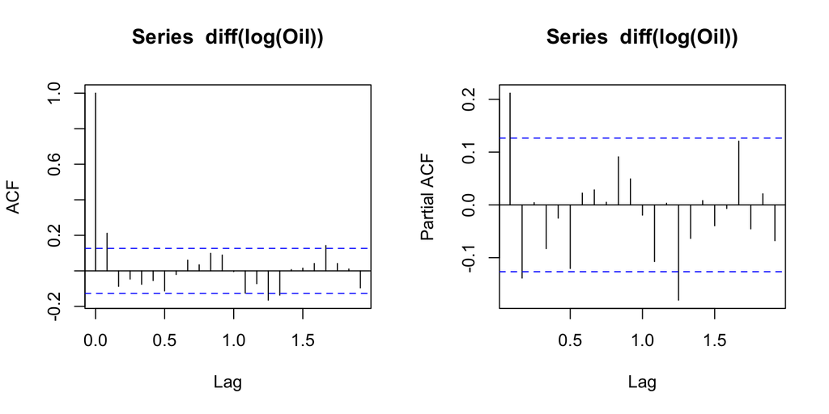

```r
  layout(matrix(1:2, 1, 2))
  acf(  diff(log(Oil)) )
  pacf( diff(log(Oil)) )
```

```r
  layout(1)
```

- we should take a log of the original price before differencing
- differencing after log makes the process stationary (Large, small, small)
- Now we will go back to the original data, and use ARIMA($p, 1, q$) model with $\lambda=0$ (Log).

## Effect of Taking Log

- Taking a log makes all price movement into relative to the current price.
- For example, 10% increase from 10 is 11. Change of +1.
- 10% increase from 50 is 55. Change of +5.
- If you take a log, then log(10) to log(11) has
  $$log(11) - log(10) = log(11/10) = log(1.1) = 0.0953$$
- On the other hand,
  $$log(55) - log(50) = log(55/50) = log(1.1) = 0.0953$$

### Another Effect of Taking Log

- Classical Decomposition
  $$Y_t = T_t + S_t + X_t$$
  where $T_t$ is a trend, $S_t$ is a seasonality, $X_t$ is a stationarty series.
- Multiplicative Model
  $$Y_t = (T_t)(S_t)(X_t)$$
- If you take a log,
  $$log(Y_t) = log(T_t) + log(S_t) + log(X_t)$$

## Model w ARIMA(p,1,q) wigh log

- we will use **lambda=0** option inside auto.arima() to take Log.

```r
  #--- Look for best ARIMA  ---
  Fit1 <- auto.arima(Oil, d=1, lambda=0, stepwise=FALSE, approximation=FALSE)
  Fit1
```

```
## Series: Oil
## ARIMA(0,1,1)
## Box Cox transformation: lambda= 0
##
## Coefficients:
##          ma1
##       0.2956
## s.e.  0.0693
##
## sigma^2 estimated as 0.006717:  log likelihood=260.29
## AIC=-516.58   AICc=-516.53   BIC=-509.62
```

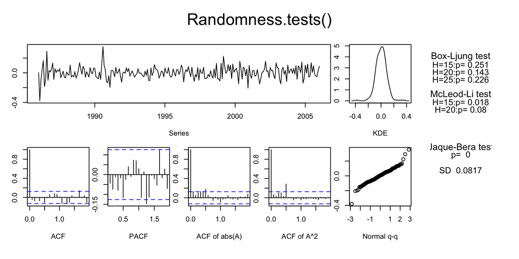

```
##   B-L test H0: the sereis is uncorrelated
##   M-L test H0: the square of the sereis is uncorrelated
##   J-B test H0: the sereis came from Normal distribution
##   SD         : Standard Deviation of the series
```

```
##       BL15  BL20  BL25  ML15 ML20 JB    SD
## [1,] 0.251 0.143 0.226 0.018 0.08  0 0.082
```

```r
  Randomness.tests(Fit1$residuals)
```

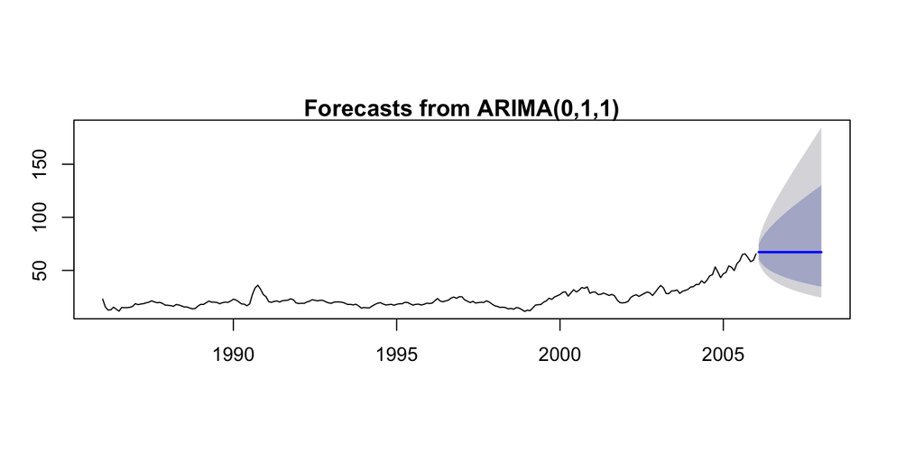

```r
  #- plot forecast of ARIMA
  plot(forecast(Fit1))
```

```r
  #- look at forecasted values
  forecast(Fit1)
```

```
##          Point Forecast    Lo 80     Hi 80    Lo 95     Hi 95
## Feb 2006       67.19173 60.49258  74.63277 57.22103  78.89982
## Mar 2006       67.19173 56.57998  79.79376 51.65874  87.39526
## Apr 2006       67.19173 53.96381  83.66215 48.05071  93.95759
## May 2006       67.19173 51.91027  86.97179 45.28255  99.70129
## Jun 2006       67.19173 50.19094  89.95108 43.00900 104.97172
## Jul 2006       67.19173 48.69896  92.70688 41.06918 109.92984
## Aug 2006       67.19173 47.37416  95.29939 39.37287 114.66598
## Sep 2006       67.19173 46.17873  97.76642 37.86358 119.23670
## Oct 2006       67.19173 45.08706 100.13358 36.50325 123.68017
## Nov 2006       67.19173 44.08093 102.41910 35.26484 128.02353
## Dec 2006       67.19173 43.14676 104.63657 34.12832 132.28688
## Jan 2007       67.19173 42.27418 106.79636 33.07843 136.48559
## Feb 2007       67.19173 41.45504 108.90664 32.10321 140.63171
## Mar 2007       67.19173 40.68277 110.97398 31.19309 144.73490
## Apr 2007       67.19173 39.95204 113.00371 30.34030 148.80303
## May 2007       67.19173 39.25841 115.00029 29.53842 152.84262
## Jun 2007       67.19173 38.59817 116.96743 28.78206 156.85914
## Jul 2007       67.19173 37.96815 118.90831 28.06668 160.85724
## Aug 2007       67.19173 37.36565 120.82563 27.38840 164.84089
## Sep 2007       67.19173 36.78833 122.72175 26.74388 168.81353
## Oct 2007       67.19173 36.23415 124.59871 26.13021 172.77816
## Nov 2007       67.19173 35.70132 126.45831 25.54484 176.73744
## Dec 2007       67.19173 35.18826 128.30214 24.98554 180.69367
## Jan 2008       67.19173 34.69356 130.13160 24.45034 184.64895
```

- ARIMA(0,1,1) was chosen by auto.arima at home AICC=-516.53.
- where is the forecast tending to?
- does it make sense to check for drift term?

```r
Arima(Oil, lambda=0, order=c(0,1,1), include.drift=TRUE)
```

```
## Series: Oil
## ARIMA(0,1,1) with drift
## Box Cox transformation: lambda= 0
##
## Coefficients:
##          ma1   drift
##       0.2939  0.0041
## s.e.  0.0696  0.0068
##
## sigma^2 estimated as 0.006735:  log likelihood=260.47
## AIC=-514.94   AICc=-514.83   BIC=-504.49
```

# 3. Rolling 1-step prediction ARIMA(p,1,d)

```r
  #--- Rolling 1-period forecast with ARIMA
  library(forecast)

  Y <- Oil                   # Original data
  window.size <- 200         # Window size for estimation
  Arima.order <- c(0,1,1)    # Arima(p,d,q) order
  pred.plot   <- TRUE        # do you want plot at end?

  # Arima() options:
  include.mean = TRUE        #
  include.drift = FALSE      #
  lambda = 0                 # 1=no transformaton 0=Log
  xreg     = FALSE           # set to TRUE if Linear Trend is present
  seasonal = c(0, 0, 0)      # seasonal component


    Yhat  <- Yhat.CIu <- Yhat.CIl <- 0        # initialize what needs to be saved
    for (i in 1:(length(Y)-window.size)) {
      # Use Arima() with given options

      # Model Estimation
      if (xreg){
          # When Linear Trend is Present
          Fit00 <- Arima( Y[i:(i+window.size-1)],
                          order=Arima.order,
                          include.mean = include.mean,
                          include.drift = include.drift,
                          lambda = lambda,
                          seasonal = seasonal,
                          xreg=time(Y[i:(i+window.size-1)]))
      } else {
          #- When Linear Trend is Not Present
          Fit00 <- Arima( Y[i:(i+window.size-1)],
                          order=Arima.order,
                          include.mean = include.mean,
                          include.drift = include.drift,
                          lambda = lambda,
                          seasonal = seasonal)
      }

      Y.h  <- forecast(Fit00, 1)       # one step prediction
      Yhat[i]     <- Y.h$mean
      Yhat.CIu[i] <- Y.h$lower[2]
      Yhat.CIl[i] <- Y.h$upper[2]
    }
    # Yhat starts at window.size+1 up to length(Y)
    Yhat     = ts(Yhat,     start=time(Y)[window.size+1], freq=frequency(Y))
    Yhat.CIu = ts(Yhat.CIu, start=time(Y)[window.size+1], freq=frequency(Y))
    Yhat.CIl = ts(Yhat.CIl, start=time(Y)[window.size+1], freq=frequency(Y))
    Y1 = window(Y, end=time(Y)[window.size],     freq=frequency(Y))
    Y2 = window(Y, start=time(Y)[window.size+1], freq=frequency(Y))

    #- Calculate prediction performance
    Pred.error = Y2 - Yhat
    Pred.rMSE =  sqrt(  mean( (Pred.error)^2 ) )     # prediction root Mean Squared Error
    print(paste("Last ", (length(Y)-window.size), " obs fit retrospectively"))
```

```
## [1] "Last  41  obs fit retrospectively"
```

```r
    print(paste("    with Rolling 1-step prediction"))
```

```
## [1] "    with Rolling 1-step prediction"
```

```r
    print(paste("  Average prediction error ", round(mean(Pred.error), 4)))
```

```
## [1] "  Average prediction error  0.6882"
```

```r
    print(paste("  root Mean Squared Error", round(Pred.rMSE, 4)))
```

```
## [1] "  root Mean Squared Error 3.4253"
```

[figure not shown]

```r
  if (pred.plot) {
    #- Plot the prediction result with original data
    layout(matrix(c(1,1,1,1,1,1,2,3,4), 3, 3, byrow=TRUE))    # 3 plots at once

    plot(  Y,  type="n")
    lines( Y1, type="o", main="Rolling 1-step prediction (Red=Actual, Blue=Prediction)" )
    lines( Y2,       type="o", col="red")
    lines( Yhat,     type="o", col="blue")
    lines( Yhat.CIu, type="l", col="gray30", lty=2)
    lines( Yhat.CIl, type="l", col="gray30", lty=2)

    # - Plot the prediction error
    plot( (window.size+1):length(Y), Pred.error, type="o", main="Prediction Error (Red-Blue)" )
    abline(h=0, lty=2)
    acf(Pred.error)
    layout(1)                    # reset the layout
  }
```

## Now available as a function!!

```
##
## Last  41  obs fit retrospectively
##     with Rolling 1-step prediction
##   Average prediction error:  0.6882
##   root Mean Squared Error:   3.4253
```

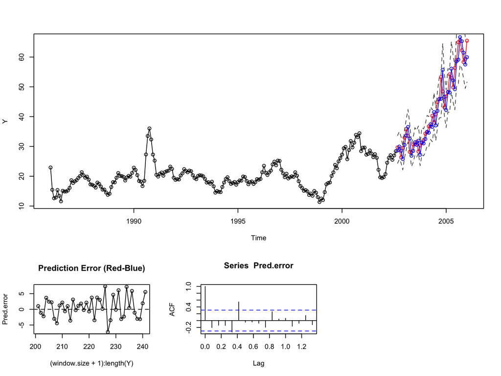

```
##      mean pred error   rMSE
## [1,]          0.6882 3.4253
```

```r
  #--- This line will load it to R
  source('https://nmimoto.github.io/R/TS-00.txt')


  #--- Set options (same as above)
  Y <- Oil                   # Original data
  window.size <- 200         # Window size for estimation
  Arima.order <- c(0,1,1)    # Arima(p,d,q) order
  pred.plot   <- TRUE        # do you want plot at end?

  # Arima() options:
  include.mean = TRUE        #
  include.drift = FALSE      #
  lambda = 0                 # 1=no transformaton 0=Log
  xreg     = FALSE           # set to TRUE if Linear Trend is present
  seasonal = c(0, 0, 0)      # seasonal component


  #--- Use the function
  Rolling1step.forecast(Y, window.size, Arima.order, pred.plot,
                        include.mean, include.drift, lambda, xreg, seasonal)
```

# Summary

#### ARIMA forecast is basically ARMA forecast added to the last observation.

#### Rolling 1-step forecast now available as function.

#### It is in same folder as Randomness.tests() and Stationarity.tests().

[TS Class Webpage](https://nmimoto.github.io/477/) – [R resource page](https://nmimoto.github.io/R/)